# HooDEE - Counting of votes

The HooDEE Committee

January 12th, 2023

# Data

First of all, let’s remember the logos that were voted on:

[figure not shown]

The data table collected is as follows: each voter (row) gave each logo (column) a note, which is an integer between 0 and 6 (rows), 0 being the worst score and 6 the best. Here is an extract:

```r
data_raw = read.table("votes.txt", h = T)
head(data_raw)
```

```
##   logo1 logo2 logo3 logo4 logo5 logo6 logo7 logo8 logo9 logo10
## 1     5     4     6     1     2     1     2     0     0      0
## 2     0     0     0     3     2     4     1     6     0      5
## 3     2     6     6     6     5     3     1     2     3      1
## 4     0     0     0     3     6     3     0     0     0      0
## 5     4     3     3     1     5     4     4     3     0      3
## 6     1     1     0     1     6     4     1     1     1      1
```

No data transformation is required.

The number of voters who participated is determined:

```r
nObs = nrow(data_raw)
print(nObs)
```

```
## [1] 122
```

Which is quite a success! Unfortunately, we did not set up systems to prevent ballot box stuffing, since each participant had the opportunity to vote more than once if they wanted to. We hope that the unfairness of this kind of behavior was widely recognized and that no cheating was committed.

# Ranking

To establish the outcome of a majority judgment vote, it is simply necessary to establish the median of the notes given to each proposal. The proposal with the highest median wins. In the case of a tie, the percentage of votes above this median is used to break it.

Here we go:

```r
data.res = data_raw %>%
  gather("logo", "note", 1:10) %>%
  group_by(logo) %>%
  summarise(med = median(note)) %>%
  arrange(desc(med)) %>%
  mutate(rank = rank(-med))

print(data.res)
```

```
## # A tibble: 10 × 3
##    logo     med  rank
##    <chr>  <dbl> <dbl>
##  1 logo1      3   3.5
##  2 logo3      3   3.5
##  3 logo4      3   3.5
##  4 logo5      3   3.5
##  5 logo6      3   3.5
##  6 logo8      3   3.5
##  7 logo10     2   7.5
##  8 logo2      2   7.5
##  9 logo7      1   9
## 10 logo9      0  10
```

**Technical details:** this pipe starts by rearranging the table by creating only two columns, a `logo` column and a `note` column. Each row corresponds to a note given to a logo by a voter. Then the function `group_by` will allow to make calculations by grouping the sets of values to be considered together by logo: we treat the notes of each logo separately. The function `summarise` allows then to calculate the median of the notes (by logo, thanks to `group_by`). This creates a smaller table where each logo will be represented by a row and where we will have a logo column and a median column. We then use the function `arrange` to sort the rows in descending order according to the median. Finally we use the function `mutate` to add a column `rank` which assigns to each row according to the median column a rank.

We notice that 6 logos tied because they all have the same median.

We therefore redo the analysis by taking into account the proportion of scores above the median:

```r
data.res = data_raw %>%
  gather("logo", "note", 1:10) %>%
  group_by(logo) %>%
  summarise(med = median(note),
            prop = sum(note>med)/nObs) %>%
  arrange(desc(med+prop)) %>%
  mutate(rank = rank(-med-prop))

print(data.res)
```

```
## # A tibble: 10 × 4
##    logo     med  prop  rank
##    <chr>  <dbl> <dbl> <dbl>
##  1 logo4      3 0.475   1.5
##  2 logo5      3 0.475   1.5
##  3 logo3      3 0.443   3.5
##  4 logo6      3 0.443   3.5
##  5 logo1      3 0.393   5.5
##  6 logo8      3 0.393   5.5
##  7 logo10     2 0.475   7
##  8 logo2      2 0.434   8
##  9 logo7      1 0.393   9
## 10 logo9      0 0.467  10
```

We therefore redo the analysis by looking at the proportion of scores above the median + 1.

```r
data.res = data_raw %>%
  gather("logo", "note", 1:10) %>%
  group_by(logo) %>%
  summarise(med = median(note),
            prop = sum(note>(med+1))/nObs) %>%
  arrange(desc(med+prop)) %>%
  mutate(rank = rank(-med-prop))

print(data.res)
```

```
## # A tibble: 10 × 4
##    logo     med  prop  rank
##    <chr>  <dbl> <dbl> <dbl>
##  1 logo5      3 0.369     1
##  2 logo4      3 0.352     2
##  3 logo3      3 0.311     3
##  4 logo6      3 0.303     4
##  5 logo8      3 0.238     5
##  6 logo1      3 0.180     6
##  7 logo10     2 0.336     7
##  8 logo2      2 0.172     8
##  9 logo7      1 0.328     9
## 10 logo9      0 0.262    10
```

And we have a winner! It is the logo 5.

# Plotting

Here are some more or less interesting plots to have a graphic visualization of these results.

## PCA

PCA on the votes, each point is a vote. The proximity of the corresponding ellipses of two logos represents the tendency of voters to vote identically for them.

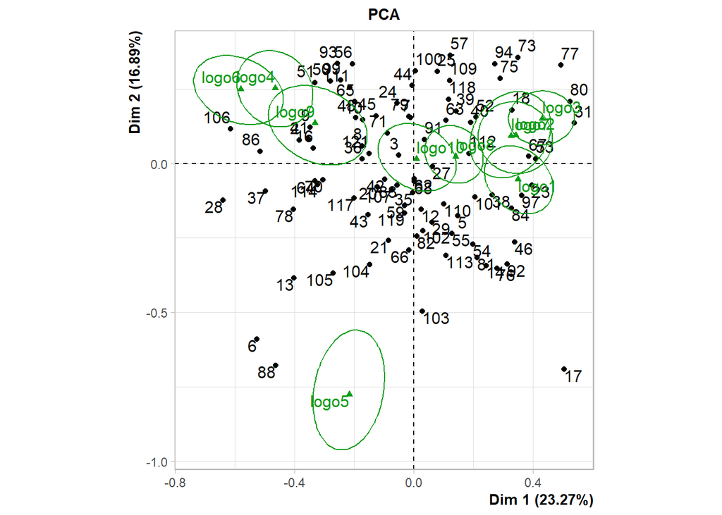

```r
res.CA<-CA(data_raw,graph=FALSE)
ellipseCA(res.CA,ellipse=c('col'),title="PCA",col.row='#050505',col.col='#0C9C16')
```

## Stacked barplot

Distribution in stacked barplot of the note distribution for each logo:

```r
data.plot1 = data_raw %>%
  gather("logo", "note", 1:10) %>%
  group_by(logo, note) %>%
  summarise(n = n()) %>%
  full_join(expand.grid(logo = paste0("logo", 1:10), note = 0:6, n2 = 1)) %>%
  select(-n2) %>%
  mutate(n = replace(n, is.na(n), 0),
         note = as.factor(note))
```

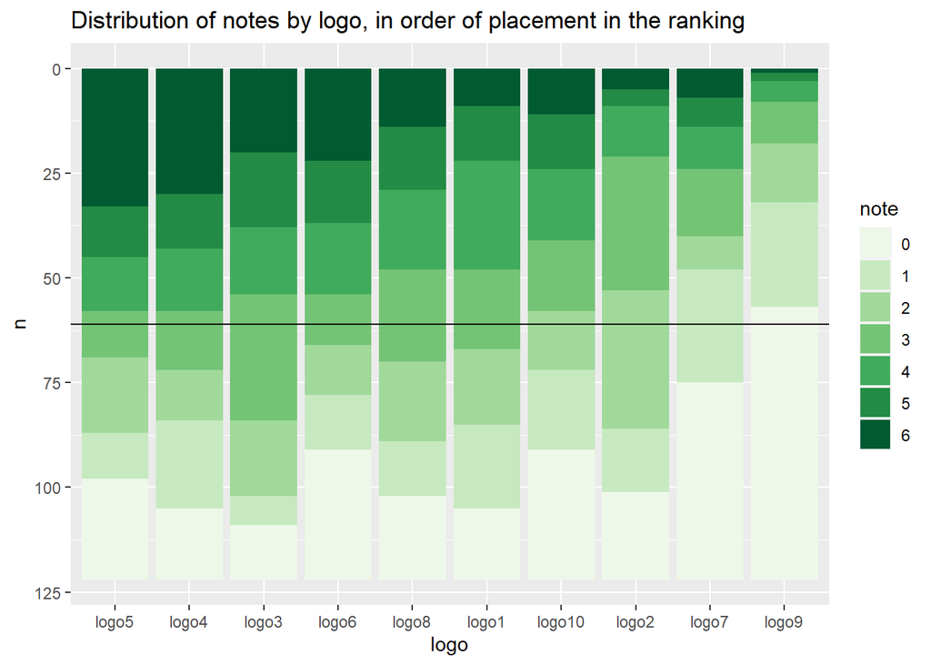

```r
data.plot1$logo <- factor(data.plot1$logo, levels = data.res$logo)

g1 = ggplot(data.plot1, aes(x = logo, y = n, fill = note)) +
  geom_bar(position="stack", stat="identity") +
  geom_hline(yintercept = nObs/2) +
  scale_fill_brewer(palette = "Greens") +
  scale_y_reverse() +
  ggtitle("Distribution of notes by logo, in order of placement in the ranking")

print(g1)
```

## Histogram

Distribution of notes in the form of a histogram.

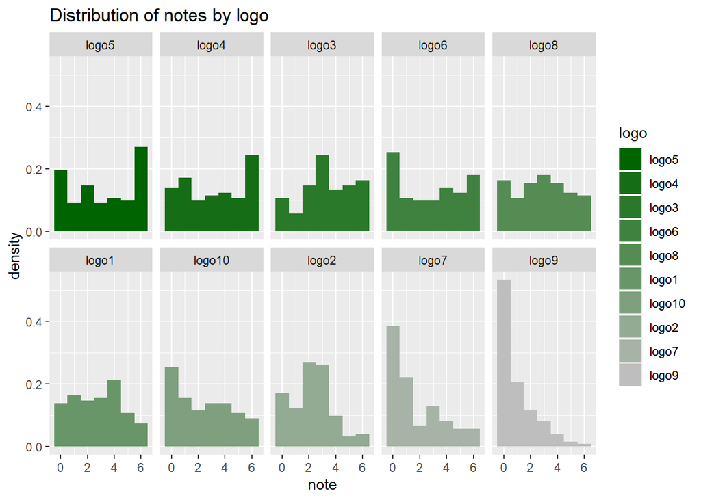

```r
data.plot2 = data_raw %>%
  gather("logo", "note", 1:10)

data.plot2$logo <- factor(data.plot2$logo, levels = data.res$logo)

g2 = ggplot(data.plot2, aes(x = note, y = ..density.., fill = logo)) +
  geom_histogram(bins = 7) +
  facet_wrap(facets = vars(logo), nrow = 2, ncol = 5) +
  scale_fill_manual(values = colorRampPalette(c("darkgreen", "grey"))(10)) +
  ggtitle("Distribution of notes by logo")

print(g2)
```